# Spam

Matt Richey

4/13/2020

# The question

1. What is the best model for predicting Spam?
2. What about True Positives vs True Negatives? These are not necessarily equally bad. Build a defensible cost matrix for spam detection and build the best model for minimizing the cost of spam.

# Data

```r
dataDir <- "/Users/shawnchen/Desktop"
dataFile <- "SpamData.csv"
spam.df <- read.csv(file.path(dataDir,dataFile))
head(spam.df)
```

```
##    C01  C02  C03 C04  C05  C06  C07  C08  C09  C10  C11  C12  C13  C14  C15
## 1 0.21 0.28 0.50   0 0.14 0.28 0.21 0.07 0.00 0.94 0.21 0.79 0.65 0.21 0.14
## 2 0.06 0.00 0.71   0 1.23 0.19 0.19 0.12 0.64 0.25 0.38 0.45 0.12 0.00 1.75
## 3 0.00 0.00 0.00   0 0.63 0.00 0.31 0.63 0.31 0.63 0.31 0.31 0.31 0.00 0.00
## 4 0.00 0.00 0.00   0 0.63 0.00 0.31 0.63 0.31 0.63 0.31 0.31 0.31 0.00 0.00
## 5 0.00 0.00 0.00   0 1.85 0.00 0.00 1.85 0.00 0.00 0.00 0.00 0.00 0.00 0.00
## 6 0.00 0.00 0.00   0 1.92 0.00 0.00 0.00 0.00 0.64 0.96 1.28 0.00 0.00 0.00
##    C16  C17  C18  C19  C20  C21 C22  C23  C24 C25 C26 C27 C28 C29 C30 C31 C32
## 1 0.14 0.07 0.28 3.47 0.00 1.59   0 0.43 0.43   0   0   0   0   0   0   0   0
## 2 0.06 0.06 1.03 1.36 0.32 0.51   0 1.16 0.06   0   0   0   0   0   0   0   0
## 3 0.31 0.00 0.00 3.18 0.00 0.31   0 0.00 0.00   0   0   0   0   0   0   0   0
## 4 0.31 0.00 0.00 3.18 0.00 0.31   0 0.00 0.00   0   0   0   0   0   0   0   0
## 5 0.00 0.00 0.00 0.00 0.00 0.00   0 0.00 0.00   0   0   0   0   0   0   0   0
## 6 0.96 0.00 0.32 3.85 0.00 0.64   0 0.00 0.00   0   0   0   0   0   0   0   0
##   C33 C34 C35 C36  C37 C38 C39  C40 C41 C42  C43 C44  C45  C46 C47 C48  C49
## 1   0   0   0   0 0.07   0   0 0.00   0   0 0.00   0 0.00 0.00   0   0 0.00
## 2   0   0   0   0 0.00   0   0 0.06   0   0 0.12   0 0.06 0.06   0   0 0.01
## 3   0   0   0   0 0.00   0   0 0.00   0   0 0.00   0 0.00 0.00   0   0 0.00
## 4   0   0   0   0 0.00   0   0 0.00   0   0 0.00   0 0.00 0.00   0   0 0.00
## 5   0   0   0   0 0.00   0   0 0.00   0   0 0.00   0 0.00 0.00   0   0 0.00
## 6   0   0   0   0 0.00   0   0 0.00   0   0 0.00   0 0.00 0.00   0   0 0.00
##     C50 C51   C52   C53   C54   C55 C56  C57 IsSpam
## 1 0.132   0 0.372 0.180 0.048 5.114 101 1028      1
## 2 0.143   0 0.276 0.184 0.010 9.821 485 2259      1
## 3 0.137   0 0.137 0.000 0.000 3.537  40  191      1
## 4 0.135   0 0.135 0.000 0.000 3.537  40  191      1
## 5 0.223   0 0.000 0.000 0.000 3.000  15   54      1
## 6 0.054   0 0.164 0.054 0.000 1.671   4  112      1
```

# Penalized Regression

Start with penalized regression

Build the data

```r
names(spam.df)
```

```
##  [1] "C01"    "C02"    "C03"    "C04"    "C05"    "C06"    "C07"    "C08"
##  [9] "C09"    "C10"    "C11"    "C12"    "C13"    "C14"    "C15"    "C16"
## [17] "C17"    "C18"    "C19"    "C20"    "C21"    "C22"    "C23"    "C24"
## [25] "C25"    "C26"    "C27"    "C28"    "C29"    "C30"    "C31"    "C32"
## [33] "C33"    "C34"    "C35"    "C36"    "C37"    "C38"    "C39"    "C40"
## [41] "C41"    "C42"    "C43"    "C44"    "C45"    "C46"    "C47"    "C48"
## [49] "C49"    "C50"    "C51"    "C52"    "C53"    "C54"    "C55"    "C56"
## [57] "C57"    "IsSpam"
```

```r
with(spam.df,table(IsSpam))
```

```
## IsSpam
##    0    1
## 2788 1812
```

```r
numPreds <- ncol(spam.df)-1
spam.x <- data.matrix(spam.df[,1:numPreds])
spam.y <- data.matrix(spam.df[,-(1:numPreds)])
```

```r
lambda.grid <- 10^seq(-5,1,length=50)
ridge.cv <- cv.glmnet(spam.x,spam.y,
                      lambda=lambda.grid,
                      family="binomial",
                      type.measure="class",
                      alpha=0)
```

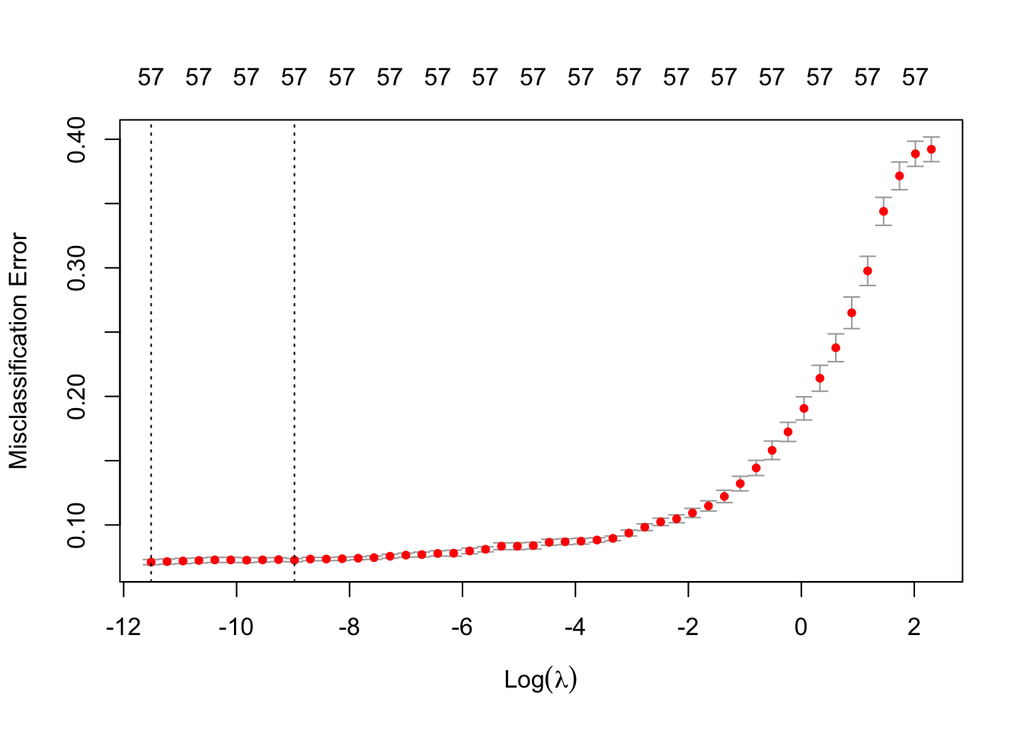

```r
plot(ridge.cv)
```

```r
lambda.opt <- ridge.cv$lambda.1se
id <- with(ridge.cv,which(lambda==lambda.opt))
(err.ridge <- with(ridge.cv,cvm[id]))
```

```
## [1] 0.0726087
```

Repeat with Lasso

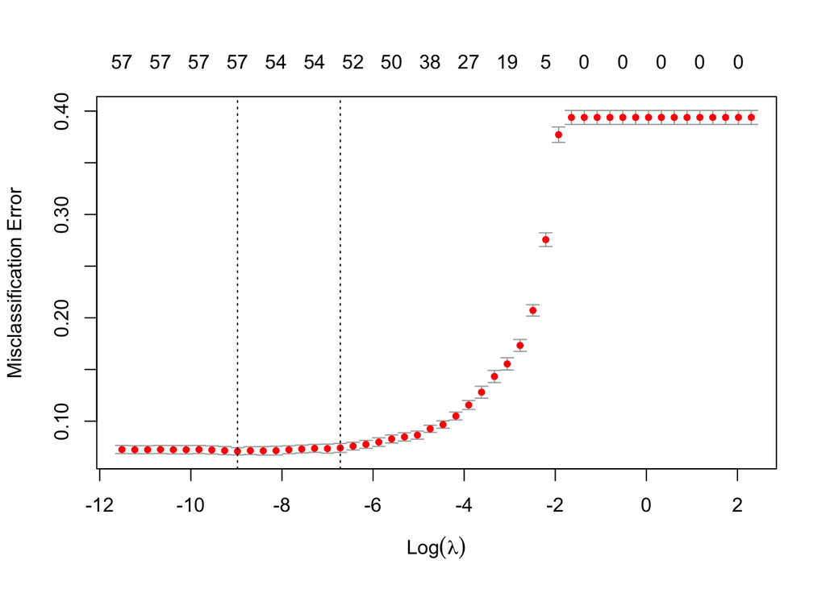

```r
lasso.cv <- cv.glmnet(spam.x,spam.y,
                      lambda=lambda.grid,
                      family="binomial",
                      type.measure="class",
                      alpha=1)
plot(lasso.cv)
```

```r
lambda.opt <- lasso.cv$lambda.1se
id <- with(lasso.cv,which(lambda==lambda.opt))
(err.lasso <- with(lasso.cv,cvm[id]))
```

```
## [1] 0.07413043
```

```r
lasso.cv$nzero[id]
```

```
## s32
##  53
```

```r
dim(spam.x)
```

```
## [1] 4600   57
```

```r
lasso.opt <- glmnet(spam.x,spam.y,
                      lambda=lambda.opt,
                      family="binomial",
                      alpha=1)
coefs <- coefficients(lasso.opt)
lassoPreds <- which(coefs != 0)
(lassoPreds <- lassoPreds[-1]-1)
```

```
##  [1]  1  2  3  4  5  6  7  8  9 10 11 12 14 15 16 17 18 19 20 21 22 23 24 25 26
## [26] 27 28 29 30 31 33 35 36 37 38 39 40 41 42 43 44 45 46 47 48 49 50 51 52 53
## [51] 54 56 57
```

What the heck, let’s build a logistic regression model

```r
spam.red.df <- spam.df[,c(lassoPreds,ncol(spam.df))]
## Build a train/test
N <- nrow(spam.red.df)
train <- sample(1:N,N/2,rep=F)
train.df <- spam.red.df[train,]
test.df <- spam.red.df[-train,]
mod.log <- glm(IsSpam ~ ., data=train.df,
               family="binomial")
preds <- predict(mod.log,newdata=test.df,type="response") > 0.5
with(test.df,table(IsSpam,preds))
```

```
##       preds
## IsSpam FALSE TRUE
##      0  1332   65
##      1   116  787
```

```r
with(test.df,mean((IsSpam==1) != preds))
```

```
## [1] 0.07869565
```

```r
numFolds <- 10
N <- nrow(spam.df)
folds <- sample(1:numFolds,N,rep=T)
errs <- numeric(numFolds)
for(fold in 1:numFolds){
  train.df <- spam.red.df[folds != fold,]
  test.df <- spam.red.df[folds == fold,]
  mod.log <- glm(IsSpam ~ .,
                 data=train.df,
                 family="binomial")
  preds <- predict(mod.log,
                   newdata=test.df,type="response") > 0.5
  errs[fold] <- with(test.df,mean((IsSpam==1) != preds))
}
c(mean(errs),sd(errs))
```

```
## [1] 0.07535053 0.01205565
```

```r
errs
```

```
##  [1] 0.08000000 0.07300885 0.09282700 0.07505519 0.07223476 0.07860262
##  [7] 0.09108911 0.06991525 0.04966140 0.07111111
```

```r
(err.log <- mean(errs))
```

```
## [1] 0.07535053
```

```r
c(err.ridge,err.lasso,err.log)
```

```
## [1] 0.07260870 0.07413043 0.07535053
```

# KNN

Check to see if the data are scaled

```r
summary(apply(spam.x,2,mean))
```

```
##      Min.   1st Qu.    Median      Mean   3rd Qu.      Max.
##   0.00545   0.06485   0.10287   6.15077   0.23947 283.29043
```

Nope

```r
spam.x <- scale(spam.x)
summary(apply(spam.x,2,mean))
```

```
##       Min.    1st Qu.     Median       Mean    3rd Qu.       Max.
## -4.738e-17 -1.329e-17 -4.334e-18 -4.007e-18  7.814e-18  4.167e-17
```

Much better

```r
N <- nrow(spam.x)
kVal <- 10
knnERR_SE <- function(kVal,numFolds=10){
  folds <- sample(1:numFolds,N,rep=T)
  errs <- numeric(numFolds)
  for(fold in 1:numFolds){
    train.x <- spam.x[folds != fold,]
    train.y <- spam.y[folds != fold]
    test.x <- spam.x[folds == fold,]
    test.y <-  spam.y[folds == fold]
    mod.knn <- knn(train.x,test.x,train.y,k=kVal)
    length(mod.knn)
    length(test.y)
    table(mod.knn,test.y)
    errs[fold] <- mean(mod.knn != test.y)
  }
  c(mean(errs),sd(errs))
}
## just the M
knnERR <- function(kVal,numFolds=10){ knnERR_SE(kVal,numFolds)[1]}

knnERR(1)
```

```
## [1] 0.08691238
```

```r
knnERR(4)
```

```
## [1] 0.09270793
```

```r
knnERR(10)
```

```
## [1] 0.09326866
```

```r
knnERR(20)
```

```
## [1] 0.09713421
```

```r
knnERR(30)
```

```
## [1] 0.1031173
```

```r
maxK <- 20
kVals <- 1:maxK
allErrs <- map_dbl(kVals,knnERR)
```

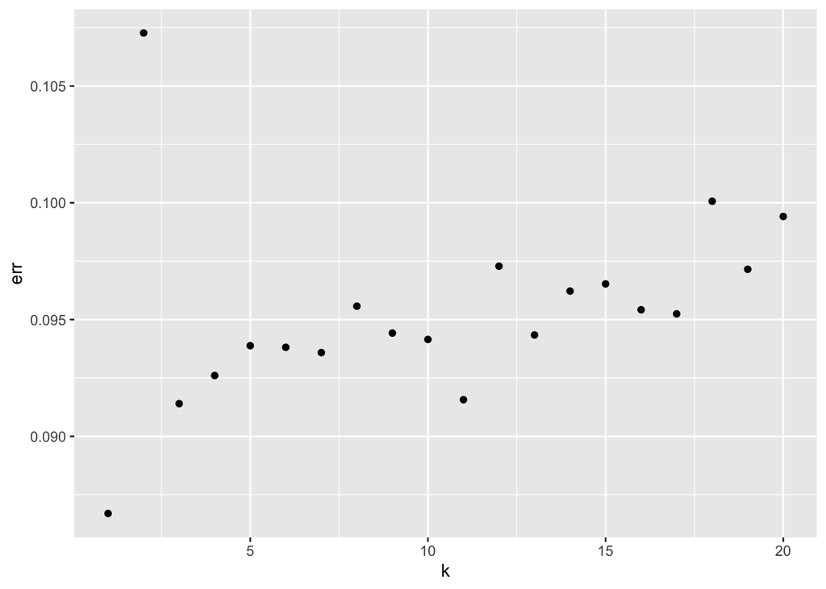

```r
data.frame(k=kVals,err=allErrs) %>%
    ggplot()+
    geom_point(aes(k,err))
```

KNN appears to be having a real hard time. Part of the problem is the large number of predictors.

```r
min(allErrs)
```

```
## [1] 0.08669759
```

This error rate is not competitive with what we saw earlier.

## Cost function

Let’s use the a cost function with the following values.

```r
true.pos <- -10
true.neg <- 0
false.pos <- 500
false.neg <- 10

addCost <- function(act,pred){
  if(act & pred)
    return(true.pos)
  if(act & !pred)
    return(false.neg)
  if(!act & pred)
    return(false.pos)
  if(!act & !pred)
    return(true.neg)
}
## Check
addCost(FALSE,TRUE)
```

```
## [1] 500
```

```r
addCost(TRUE,FALSE)
```

```
## [1] 10
```

```r
addCost(TRUE,TRUE)
```

```
## [1] -10
```

```r
addCost(FALSE,FALSE)
```

```
## [1] 0
```

We’ll use penalized regression to build the probability model.

Of course, we’ll use the train/test data

```r
N <- nrow(spam.df)
train <- sample(1:N,N/2,rep=F)
train.df <- spam.df[train,]
test.df <- spam.df[-train,]

train.x <- data.matrix(train.df[,1:numPreds])
train.y <- data.matrix(train.df[,-(1:numPreds)])
test.x <- data.matrix(test.df[,1:numPreds])
test.y <- data.matrix(test.df[,-(1:numPreds)])
```

```r
mod.ridge <- glmnet(train.x,
                    train.y,
                    alpha = 0,
                    family="binomial",
                    lambda = lambda.opt)
probs.ridge <- predict(mod.ridge,
                       family="binomial",
                       newx=test.x,
                       type="response")
```

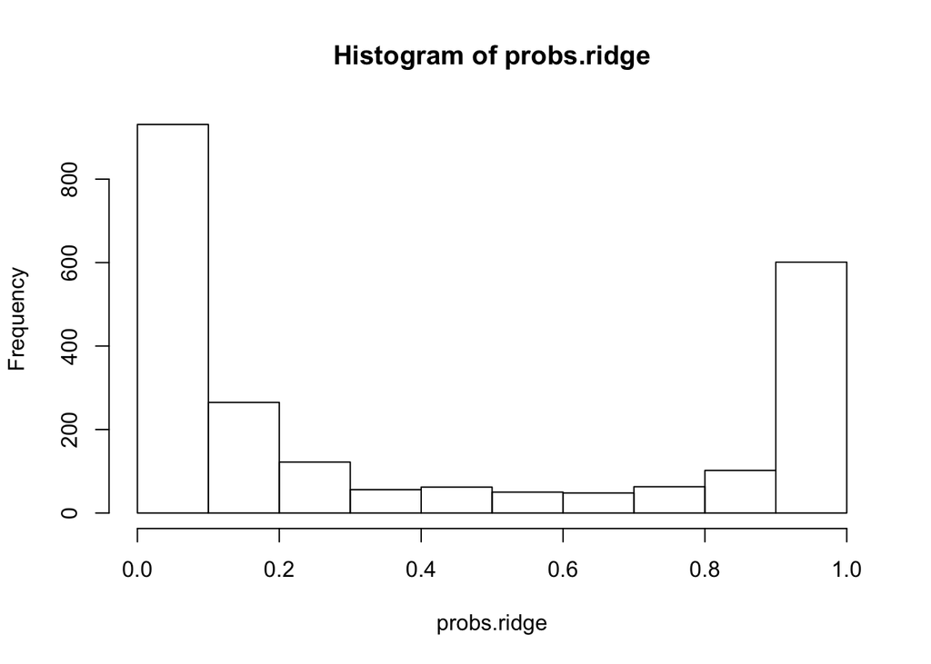

```r
hist(probs.ridge)
```

Add predictions and compute the total cost as a function of a prob threshold

```r
prob.thresh <- .50
totCost <- function(prob.thresh){
  test.df %>%
    select(IsSpam) %>%
    mutate(pred =  probs.ridge > prob.thresh) %>%
    rowwise() %>%
    mutate(cost=addCost(IsSpam == 1,pred))%>%
    with(sum(cost))
}
```

Ok, here we go..

```r
true.pos <- -10
true.neg <- 0
false.pos <- 40
false.neg <- 20

probs <- seq(0,1,length=50)
allCost <- map_dbl(probs, totCost)
```

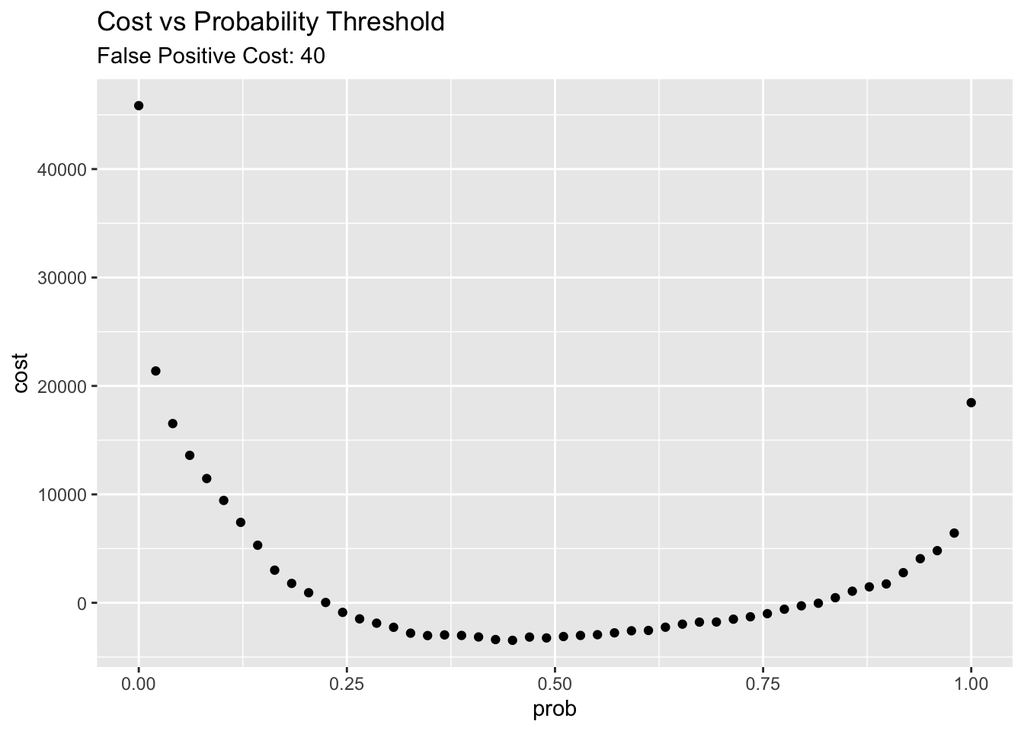

```r
data.frame(prob=probs,cost=allCost) %>%
  ggplot()+
  geom_point(aes(prob,cost))+
  labs(title="Cost vs Probability Threshold",
       subtitle=sprintf("False Positive Cost: %s",false.pos))
```

Where is the minimum cost

```r
id <- which.min(allCost)
costMin <- allCost[id]
probOpt <- probs[id]
c(probOpt,costMin)
```

```
## [1]     0.4489796 -3460.0000000
```

Extra: Let’s compute the value of the optimal probabilty as a function of the false postive cost.

Not the most elegant function, but it will work.

```r
probOptVal <- function(falsePos){
  ## not: <<- changes the value of a global variable
  false.pos <<- falsePos
  allCost <- map_dbl(probs, totCost)
  id <- which.min(allCost)
  probs[id]
}

##Check
probOptVal(false.pos)
```

```
## [1] 0.4489796
```

```r
probOptVal(10)
```

```
## [1] 0.3469388
```

```r
probOptVal(100)
```

```
## [1] 0.5510204
```

Apply to a sequence of false positive costs

```r
falsePosVals <- seq(10,500,by=20)
optProbs <- map_dbl(falsePosVals,probOptVal)
```

And here is the plot

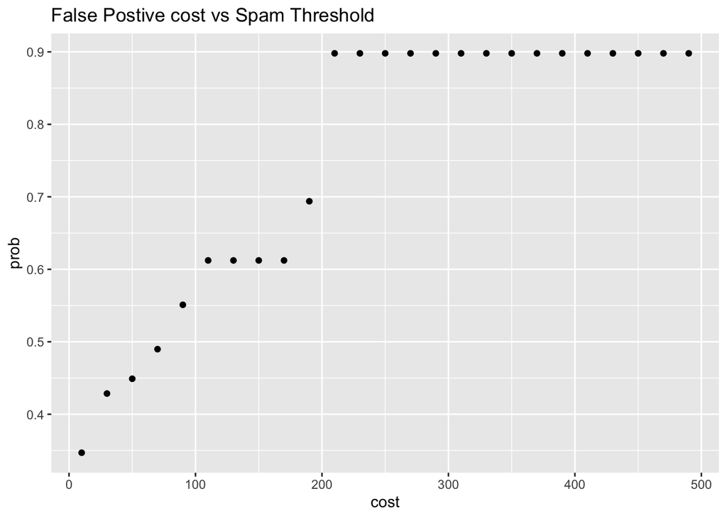

```r
data.frame(cost=falsePosVals,prob=optProbs) %>%
    ggplot()+
    geom_point(aes(cost,prob))+
  labs(title="False Postive cost vs Spam Threshold")
```

This plot shows how the threshold probability increases as the cost of a false positive increases. As the cost gets higher, we have to be more and more discriminating about Spam. At the high end, we have to be very sure that an email is spam since a mistake incures a heavy cost.